# PS2 Through R

Michael Chirico

Compiled September 11, 2016 at 12:32

## Problem 1

We can just do this directly, or we can make a function to make our code more concise. Done directly:

```r
#Part (d)
sum(exp(-4) * 4^(0:3)/factorial(0:3))
```

```
## [1] 0.4334701
```

```r
#Part (e)
sum(exp(-4) * 4^(11:12)/factorial(11:12))
```

```
## [1] 0.002566049
```

```r
#Part (f)
1 - sum(exp(-4) * 4^(0:5)/factorial(0:5))
```

```
## [1] 0.2148696
```

If we wanted to do this, we might quickly tire of copy-pasting and/or writing out all of that code over and over. That’s why functions were invented:

```r
#First, define a function
prob_days <- function(x) sum(exp(-4) * 4 ^ x / factorial(x))

#Now, the other parts become much more concise and readable:
prob_days(0:3)
```

```
## [1] 0.4334701
```

```r
prob_days(11:12)
```

```
## [1] 0.002566049
```

```r
1 - prob_days(0:5)
```

```
## [1] 0.2148696
```

We could also have defined our function more generally (wherever 4 appears in the formula, it could be replaced by any positive number). Actually, this PMF is called the Poisson PMF, and since it’s so common, R has two built-in function for it called `dpois` (giving the “density”, i.e., the value of the PMF) and `ppois` giving the CDF. We could have used this like so:

```r
ppois(3, lambda = 4)
```

```
## [1] 0.4334701
```

```r
sum(dpois(11:12, lambda = 4))
```

```
## [1] 0.002566049
```

```r
1 - ppois(5, lambda = 4)
```

```
## [1] 0.2148696
```

## Problem 2

As above, we can either define a function or just do all the computations directly. First, without a special function:

```r
#(c) (i)
sum(0:4 * choose(4, 0:4) * .55^(0:4) * (1-.55)^(4:0))
```

```
## [1] 2.2
```

```r
#(c) (ii)
choose(4, 0) * (.55)^0 * (1-.55)^4
```

```
## [1] 0.04100625
```

```r
#(c) (iii)
sum(choose(4, 3:4) * .55^(3:4) * (1-.55)^(4 - 3:4))
```

```
## [1] 0.3909813
```

```r
#(c) (iv)
20 * sum(choose(4, 0:2) * .55^(0:2) * (1-.55)^(4 - 0:2)) -
  15 * sum(choose(4, 3:4) * .55^(3:4) * (1-.55)^(4 - 3:4))
```

```
## [1] 6.315656
```

```r
#(c) (v)
100 * sum(choose(4, 3:4) * .55^(3:4) * (1-.55)^(4 - 3:4)) +
  50 * choose(4, 2) * .55^(2) * (1-.55)^(4 - 2) -
  200 * sum(choose(4, 0:1) * .55^(0:1) * (1-.55)^(4 - 0:1))
```

```
## [1] 9.17875
```

With a function:

```r
repub_prob <- function(x) choose(4, x) * .55 ^ x * (1 - .55) ^ (4 - x)

sum(0:4 * repub_prob(0:4))
```

```
## [1] 2.2
```

```r
repub_prob(0)
```

```
## [1] 0.04100625
```

```r
sum(repub_prob(3:4))
```

```
## [1] 0.3909813
```

```r
sum(c(20, 20, 20, -15, -15) * repub_prob(0:4))
```

```
## [1] 6.315656
```

```r
sum(c(-200, -200, 50, 100, 100) * repub_prob(0:4))
```

```
## [1] 9.17875
```

And once again, this PMF is common enough to warrant R having a set of built-in functions for interacting with it: importantly, `dbinom` and `pbinom` for the density (PMF) and probability (CDF), respectively. We can also, since we’re dealing with a discrete distribution, just calculate the entire distribution, store it in a vector, and extract the parts we need for each question:

```r
repub.pmf = dbinom(0:4, size = 4, prob = .55)
sum(0:4 * repub.pmf)
```

```
## [1] 2.2
```

```r
repub.pmf[1L]
```

```
## [1] 0.04100625
```

```r
sum(repub.pmf[4:5])
```

```
## [1] 0.3909813
```

```r
sum(c(20, 20, 20, -15, -15) * repub.pmf)
```

```
## [1] 6.315656
```

```r
sum(c(-200, -200, 50, 100, 100) * repub.pmf)
```

```
## [1] 9.17875
```

## Problem 4

All limits can typically be guessed by plotting. For which R is perfect!

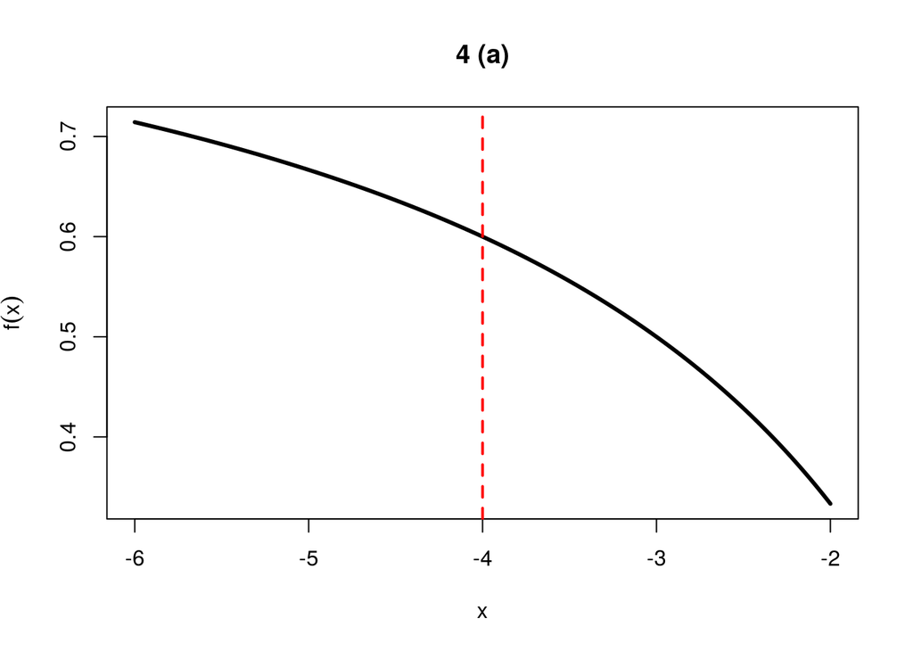

```r
# two-sided limit, so take points on both sides
x <- seq(-6, -2, length.out = 1000L)

plot(x, (x^2 + 5*x + 4)/(x^2 + 3*x - 4),
     type = "l", lwd = 3L, xlab = "x",
     ylab = expression(f(x)), main = "4 (a)")
abline(v = -4, lty = 2, lwd = 2, col = "red")
```

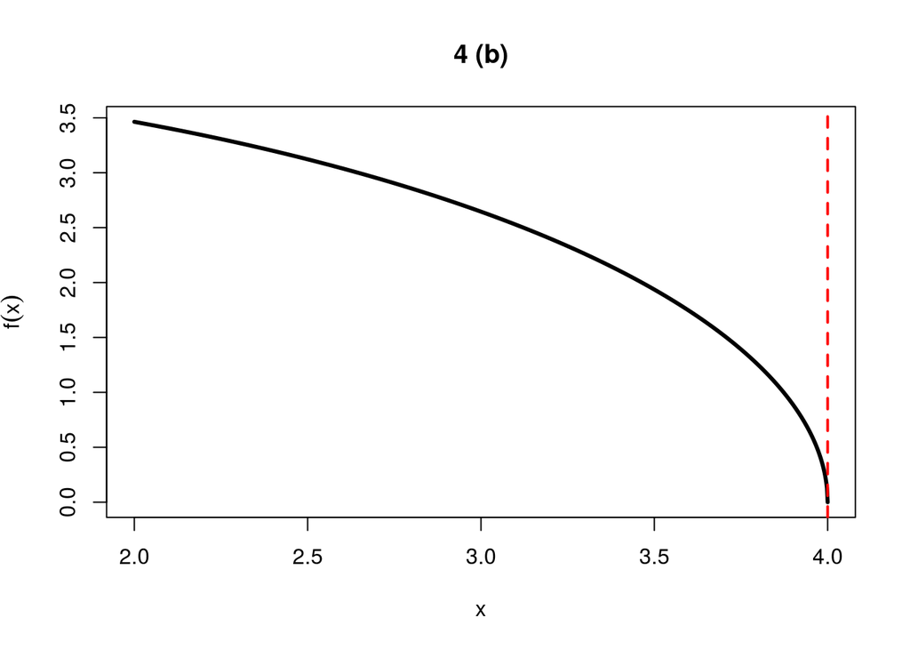

```r
# one-sided limit, so only take points from one side
x <- seq(2, 4, length.out = 1000L)
plot(x, sqrt(16 - x^2),
     type = "l", lwd = 3L, xlab = "x",
     ylab = expression(f(x)), main = "4 (b)")
abline(v = 4, lty = 2, lwd = 2, col = "red")
```

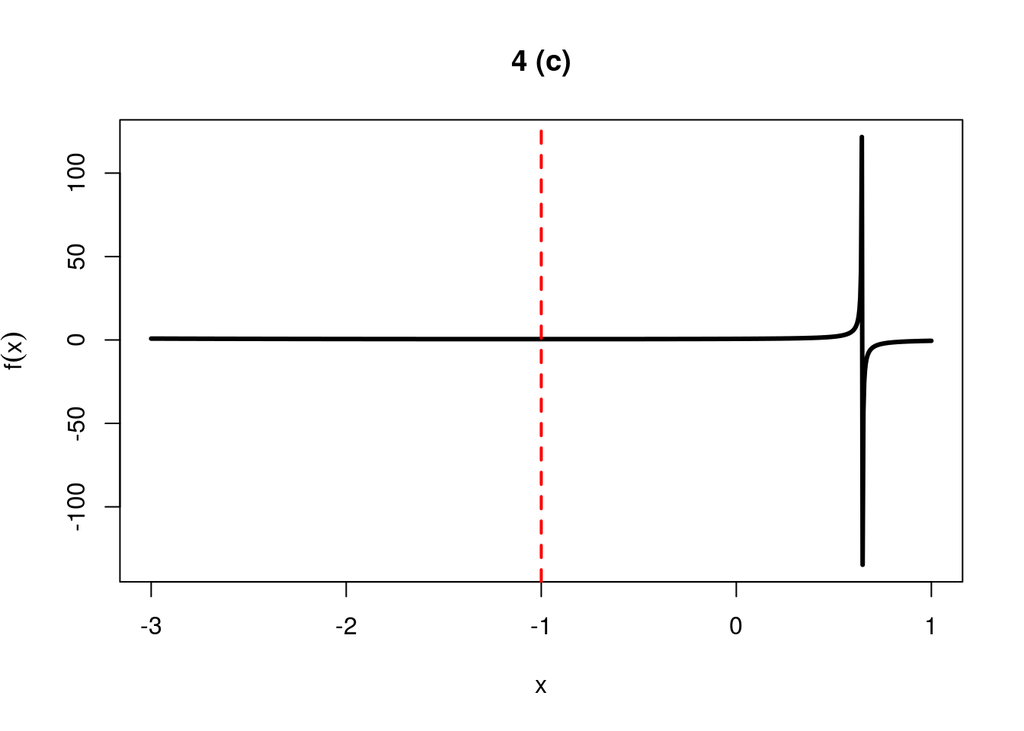

```r
# two-sided limit, so take points on both sides
x <- seq(-3, 1, length.out = 1000L)

plot(x, (x - 2)/(x^2 + 4*x - 3),
     type = "l", lwd = 3L, xlab = "x",
     ylab = expression(f(x)), main = "4 (c)")
abline(v = -1, lty = 2, lwd = 2, col = "red")
```

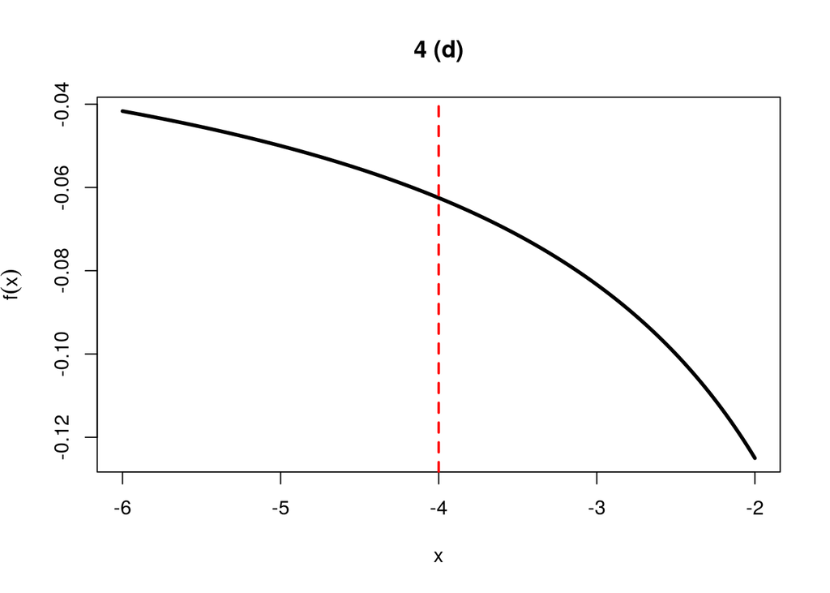

```r
# two-sided limit, so take points on both sides
x <- seq(-6, -2, length.out = 1000L)

plot(x, (1/4 + 1/x)/(4 + x),
     type = "l", lwd = 3L, xlab = "x",
     ylab = expression(f(x)), main = "4 (d)")
abline(v = -4, lty = 2, lwd = 2, col = "red")
```

## Problem 5

R has the ability to differentiate simple functions for you as well (admittedly, it’s pretty rudimentary), using the `D` function – see `?D`.

```r
D(expression(4*x^3 + 2*x^2 + 5*x + 11), "x")
```

```
## 4 * (3 * x^2) + 2 * (2 * x) + 5
```

```r
D(expression(sqrt(30)), "x")
```

```
## [1] 0
```

```r
D(expression(2^3 + (sin(x))^3), "x")
```

```
## 3 * (cos(x) * (sin(x))^2)
```

```r
D(expression(log(9*t + 1)), "t")
```

```
## 9/(9 * t + 1)
```

```r
D(expression(x^3 * cos(11*x)), "x")
```

```
## 3 * x^2 * cos(11 * x) - x^3 * (sin(11 * x) * 11)
```

```r
D(expression(log(x^2 * exp(x))), "x")
```

```
## (2 * x * exp(x) + x^2 * exp(x))/(x^2 * exp(x))
```

```r
D(expression((1/y^2 - 3/y^4) * (y + 5*y^3)), "y")
```

```
## (1/y^2 - 3/y^4) * (1 + 5 * (3 * y^2)) - (2 * y/(y^2)^2 - 3 *
##     (4 * y^3)/(y^4)^2) * (y + 5 * y^3)
```

```r
D(expression(3*t - 1/2 * t + 1), "t")
```

```
## 3 - 1/2
```

## Problem 6

R can integrate as well! See `?integrate`.

```r
integrate(function(x) x^(3/7), 0, 1)
```

```
## 0.7000001 with absolute error < 6.3e-05
```

```r
integrate(function(x) 3/x^4 + 2, 1, 2)
```

```
## 2.875 with absolute error < 3.2e-14
```

```r
integrate(function(x) 2^x, 8, 9)
```

```
## 369.3299 with absolute error < 4.1e-12
```

```r
integrate(function(x) sqrt(x^5 + 2), 3, 3)
```

```
## 0 with absolute error < 0
```